# Attempt to get temperature threshold values from the presence component of the hurdle model from Plaisted et al. 2022 using the T3 seagrass data from CACO, FIIS, ASIS

L. Feher

June 05, 2026

This report documents my attempt to get temperature threshold values using the presence component of the GAMM hurdle model described in Plaisted et al. 2022 (https://doi.org/10.3389/fmars.2022.920699). **Note that we did not end up using these threshold values in the park-specific thermal regime reports because they seemed to be way too low compared to values reported in the literature** (e.g., [Berger & Berg 2024](https://doi.org/10.3354/meps14587), [Moore & Jarvis 2008](https://doi.org/10.2112/SI55-014), [Carr et al. 2012](https://doi.org/10.3354/meps09556), [Shields et al. 2018](https://doi.org/10.3390/d10040125)) **AND they did not produce ecologically reasonable results when the metrics HDH, CDH, % time above threshold, and # of warming events were calculated** (see plots and explanation at the end)**.**

The model structure for the presence component of the GAMM hurdle model was based on R code developed by Neptune and Company Inc. saved on the NCBN file server here:  
\\files.nps.doi.net\\NPS\\WASO\\Programs\\IMD\\NCBN\\Files\\PROJECTS\\Plaisted_2022\\ncbn_seagrass\\R\\3_fit_hurdle_model.R

Eelgrass presence data were obtained from the 2025 certified T3 seagrass data package (data package code: 2316692, https://doi.org/10.57830/2316692). Water temperature data were obtained from the NPS Aquarius database on June 05, 2026. All code for downloading the T3 data from the NCBN server and querying the Aquarius database are shown in the following sections.

## Get water temp data for T3 transects

```r
# Establish connection to Aquarius
fetchaquarius::connectToAquarius("aqreadonly")

# Get raw T3 temp data from Aquarius
t3_raw_temps <- map(c("National Park Service.Northeast Coastal and Barrier Network",
                     "National Park Service.Northeast Coastal and Barrier Network.ENE_Seagrass_Continuous"), ~fetchaquarius::getLocationInfo(folder = .x)) %>%
  bind_rows() %>%
  filter(Identifier %in% c("ASIS_Seagrass_Tingles", "CACO_Seagrass_MA20_1", "CACO_Seagrass_MA20_2", "FIIS_Seagrass_GSB", "FIIS_Seagrass_MB")) %>%
  distinct() %>%
  mutate(parameters = map(Identifier, ~getTimeSeriesInfo(.x))) %>%
  select(-c(Identifier, UniqueId, UtcOffset, LastModified, Publish, Tags)) %>%
  unnest(cols = c(parameters)) %>%
  mutate(timeseries = map(Identifier, ~getTimeSeries(.x))) %>%
  select(Name, Identifier, LocationIdentifier, Unit, Label, timeseries) %>%
  mutate(data = map(timeseries, ~.x$Points)) %>%
  select(-timeseries) %>%
  unnest(cols = data) %>%
  unnest(cols = Value) %>%
  rename("Value" = Numeric) %>%
  as.data.frame %>%
  separate(., col = Timestamp, into = c("Date", "Time"), sep = " ", remove = FALSE) %>%
  mutate(Time = if_else(is.na(Time), "00:00:00", Time)) %>%
  filter(str_detect(Identifier, "Water Temp.A") | str_detect(Identifier, "Water Temp.B") | str_detect(Identifier, "Water Temp.C"))

# Get mean daily mean temp for each year
t3_mean_daily_temps <- t3_raw_temps %>%
  filter(str_detect(Identifier, "Water Temp.A")) %>% # Limit to temp data from shallowest (A) transect as in Plaisted 2022
  filter(month(Date) >= 6 & month(Date) <= 8) %>% # Filter to summer months
  # filter(month(Date) >= 5 & month(Date) <= 9) %>% # Doesn't work - gives 4 zero crossings and 2 max presence values
  group_by("loc" = Name, Date) %>%
  summarise(daily_mean_temp = mean(Value, na.rm = TRUE)) %>% # Get daily mean temp for each date
  group_by(loc, "yr" = year(Date)) %>%
  summarise(Mean_daily_mean_temp = mean(daily_mean_temp, na.rm = TRUE)) # Get mean daily mean temp for each year

# Center the temps for each site (as in Plaisted 2022)
t3_ctr_temps <- t3_mean_daily_temps %>%
  arrange(loc, yr) %>%
  ungroup() %>%
  group_by(loc) %>%
  mutate(pryr_mean_daily_mean_temp = lag(Mean_daily_mean_temp, n = 1), # assign mean daily mean temp from prior summer to each year
         site_mean_temp = mean(pryr_mean_daily_mean_temp, na.rm = TRUE), # get site-level mean daily mean temp across all years
         mc_avg_temp = pryr_mean_daily_mean_temp - site_mean_temp) # center the prior-year mean daily mean temps for each year based on the site-level means

disconnectFromAquarius()
```

## Get 2025 certified T3 seagrass data

```r
# Get certified T3 seagrass data package
t3_cover <- read_csv("//files.nps.doi.net/NPS/WASO/Programs/IMD/NCBN/Files/MONITORING/Estuarine_Eutrophication/03_ARCHIVE/Seagrass_Tier3_Quadrats/2025/Certified_Data/Tier3_Seagrass_Data_Certified_2025.csv", show_col_types = FALSE) %>%
  filter(Transect == "A" & Species == "ZM") %>% # Limit to shallowest transect as in Plaisted 2022
  mutate(pct_cover = ifelse(`Percent Cover` == 100, 0.99, `Percent Cover`/100),
         presence = ifelse(pct_cover > 0, 1, 0),
         loc = case_when( # recode locations to match temperature data
           Location == "Fire Island" ~ "Great South Bay",
           Location == "Duck Harbor Beach" ~ "Duck Harbor",
           T ~ Location
         ),
         loc_quad = factor(paste0(loc, ":", Quadrat)),
         yr = year(Date)) %>%
  filter((loc %in% c("Duck Harbor", "Pleasant Bay", "Tingles Island", "Moriches Bay") & month(Date) >= 5 & month(Date) <= 9) | # Limit to data collected during summer months - 1 sampling event per year
           (loc == "Great South Bay" & Date == as.Date("2007-07-26")) | # For 2007 at GSB, Limit to first date collected (July 26 2007)
           (loc == "Great South Bay" & yr != 2007)) %>% # Also get data from all other years at GSB
  select(loc, loc_quad, yr, pct_cover, presence)
```

## Join water temp data to seagrass presence data

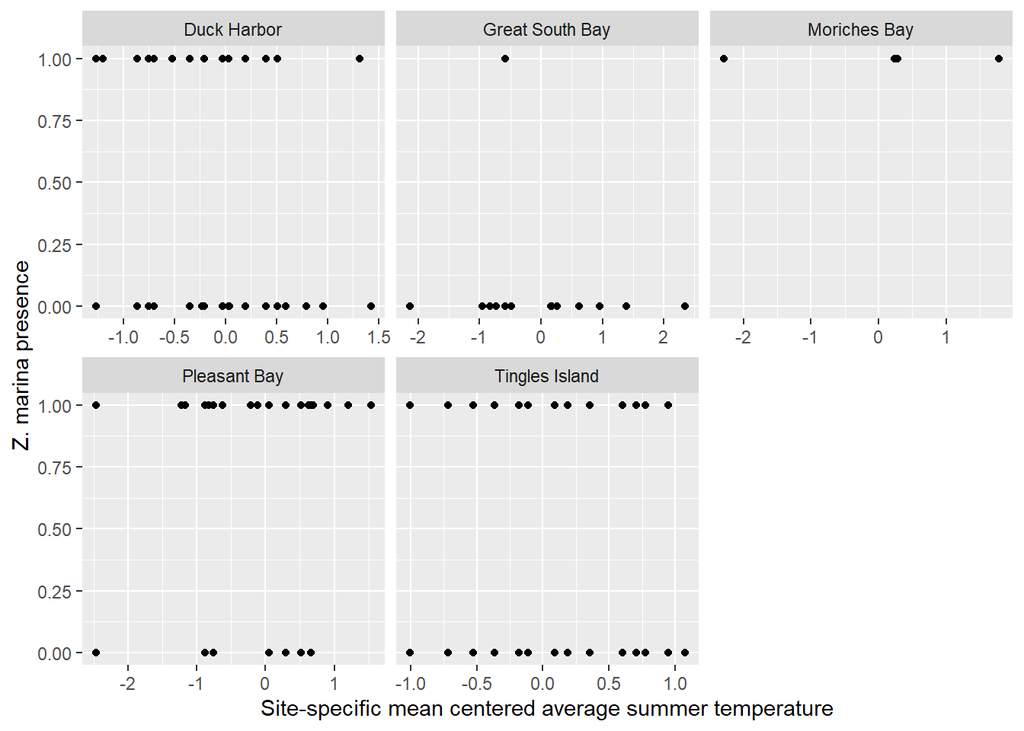

```r
t3_ctr_temps_cover <- t3_cover %>%
 left_join(., t3_ctr_temps, by = c("loc" = "loc", "yr" = "yr")) %>%
  mutate(loc = factor(loc)) %>%
  na.omit()

ggplot(data = t3_ctr_temps_cover, aes(x = mc_avg_temp, y = presence)) +
  geom_point() +
  facet_wrap(~loc, scales = "free_x") +
  xlab("Site-specific mean centered average summer temperature") +
  ylab("Z. marina presence")
```

## Run the T3 presence component GAMM

```r
# presence model
summary(t3_pres_mod <- gam(presence ~
                    s(loc, bs = "re") + s(loc_quad, bs = "re") +
                    s(mc_avg_temp) +
                    s(yr),
                  data = t3_ctr_temps_cover,
                  method = "REML",
                  family = binomial(),
                  select = TRUE))
```

[output not shown]

## Plot the partial effect of centered average water temperature

> The second spot where the line crosses the x-axis at 0 represents the temperature at which presence changes from 1 to 0.

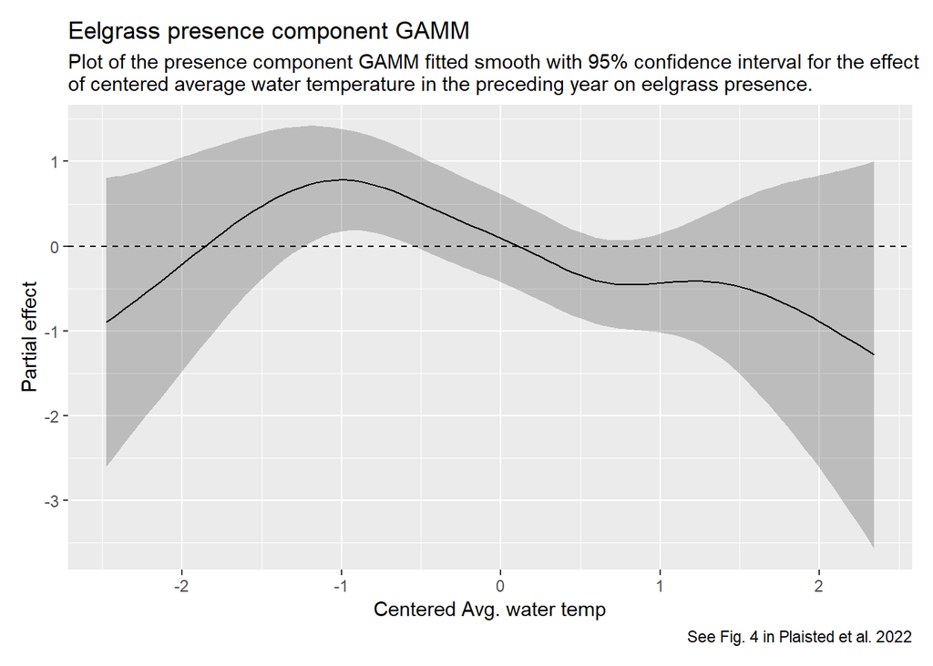

```r
draw(smooth_estimates(t3_pres_mod, "s(mc_avg_temp)")) +
  geom_hline(aes(yintercept = 0), linetype = "dashed") +
  xlab("Centered Avg. water temp") +
  ggtitle("Eelgrass presence component GAMM") +
  labs(subtitle = str_wrap("Plot of the presence component GAMM fitted smooth with 95% confidence interval for the effect of centered average water temperature in the preceding year on eelgrass presence.", width = 95),
       caption = "See Fig. 4 in Plaisted et al. 2022")
```

## Get the value of temp where the partial effects plot crosses 0 and use it to un-center the water temperatures to get a threshold value for each site.

```r
# First, get the single value where the partial effects crosses zero for all sites
model_thres_all_sites <- t3_ctr_temps %>%
  ungroup() %>%
  nest() %>%
  mutate(min_temp = map_dbl(data, ~min(.x$mc_avg_temp, na.rm = TRUE)),
         max_temp = map_dbl(data, ~max(.x$mc_avg_temp, na.rm = TRUE)),
         new_data = map2(min_temp, max_temp, ~data_slice(t3_pres_mod, mc_avg_temp = seq(.x, .y, length.out = 1000))),
         pred = map(new_data, ~predict(t3_pres_mod, newdata = .x, type = "terms")),
         smooth_y = map(pred, ~.x[, "s(mc_avg_temp)"]),
         zero_crossings = map2(new_data, smooth_y, ~.x$mc_avg_temp[which(diff(sign(.y)) != 0)]),
         dec_pres_thres = map_dbl(zero_crossings, ~.x[2])) # value of centered temp where presence switches from 1 to 0 for all sites (presence begins to decrease)

site_level_thresholds <- t3_ctr_temps %>%
  group_by(loc) %>%
  distinct(site_mean_temp) %>% # mean of mean temp for all sites
  mutate(site_dec_pres_thres_temp = site_mean_temp + model_thres_all_sites$dec_pres_thres) # value of actual temp where presence switches from 1 to 0 for each site (presence begins to decrease)

print(site_level_thresholds)
```

```
## # A tibble: 5 × 3
## # Groups:   loc [5]
##   loc             site_mean_temp site_dec_pres_thres_temp
##   <chr>                    <dbl>                    <dbl>
## 1 Duck Harbor               20.9                     21.0
## 2 Great South Bay           25.6                     25.7
## 3 Moriches Bay              23.0                     23.1
## 4 Pleasant Bay              22.6                     22.7
## 5 Tingles Island            26.9                     27.1
```

## Use the site-level temperature thresholds to calculate and plot thermal metrics

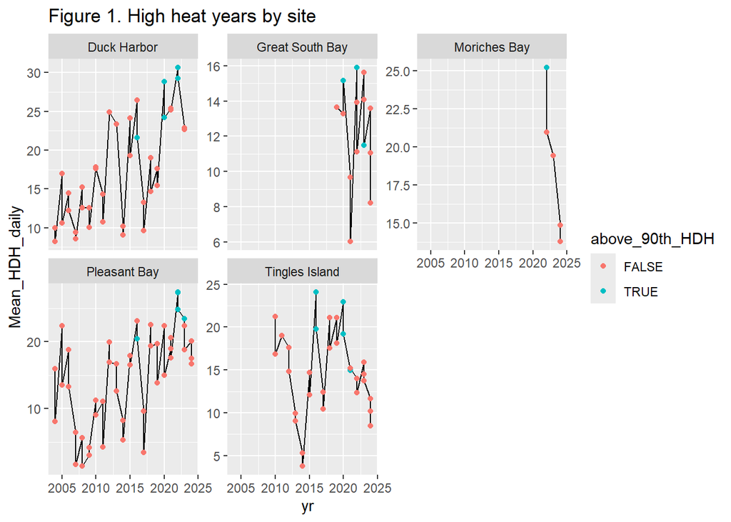

```r
# modified from https://github.com/katiebutton/Eelgrass_Resiliency/blob/main/R/Resiliency_water_temp_siteyear_25.R

# Aggregate hourly temps for each site and transect
temp_hourly <- t3_raw_temps %>%
  filter(month(Date) %in% 5:9) %>%
  group_by(Name, Label, Hour = floor_date(Timestamp, "hour")) %>%
  summarise(hourly_temp = mean(Value, na.rm = TRUE), .groups = "drop") %>%
  left_join(., site_level_thresholds, by = c("Name" = "loc")) %>%
  mutate(yr = year(Hour),
         HDH_hour = pmax(hourly_temp - site_dec_pres_thres_temp, 0),
         CDH_hour = pmin(hourly_temp - site_dec_pres_thres_temp, 0),
         above_thres = hourly_temp > site_dec_pres_thres_temp,
         Date = as.Date(Hour))

# % time above the threshold for each site and transect
site_pct_time_above <- temp_hourly %>%
  group_by(Name, Label) %>%
  summarise(site_pct_time_above = mean(above_thres)*100)

# Aggregate daily temps for each site, transect, and year
daily_data <- temp_hourly %>%
  group_by(Name, Label, yr, Date) %>%
  summarise(daily_HDH = sum(HDH_hour, na.rm = TRUE), # daily heating degree hours
            daily_CDH = sum(CDH_hour, na.rm = TRUE),
            max_temp = max(hourly_temp, na.rm = TRUE),
            min_temp = min(hourly_temp, na.rm = TRUE),
            mean_temp = mean(hourly_temp, na.rm = TRUE),
            pct_time_above = mean(above_thres) * 100,
            .groups = "drop")

# Cumulative hours above threshold for each site, transect, and year
event_hours <- temp_hourly %>%
  arrange(Name, Label, Hour) %>%
  group_by(Name, Label, yr) %>%
  mutate(event_id = cumsum(above_thres & !lag(above_thres, default = FALSE))) %>%
  filter(above_thres)

# Heating events for each site, transect, and year
warming_events <- event_hours %>%
    group_by(Name, Label, yr, event_id) %>%
    summarise(
      event_start = min(Hour),
      event_end = max(Hour),
      duration_hours = n(),
      duration_days = n() / 24,
      Total_HDH = sum(HDH_hour, na.rm = TRUE),
      max_temp = max(hourly_temp, na.rm = TRUE),
      mean_temp = mean(hourly_temp, na.rm = TRUE),
      .groups = "drop"
    ) %>%
    arrange(Name, Label, yr, desc(Total_HDH))

# % time above the threshold for each site, transect, and year
site_pct_time_above_by_year <- temp_hourly %>%
  group_by(Name, Label, yr) %>%
  summarise(Site_pct_time_above = mean(above_thres) * 100,
            .groups = "drop")

# Cumulative heating events for each site, transect, and year
event_summary_by_year <- daily_data %>%
    distinct(Name, Label, yr) %>%          # ensures all years are present
    left_join(
      warming_events %>%
        group_by(Name, Label, yr) %>%
        summarise(
          Number_warming_events = n(),
          Mean_warming_event_duration_days = if (n() > 0) mean(duration_days) else 0,
          SE_warming_event_duration_days   = if (n() > 0) sd(duration_days) / sqrt(n()) else 0,
          .groups = "drop"
        ),
      by = c("Name", "Label", "yr")
    ) %>%
    mutate(
      Number_warming_events            = replace_na(Number_warming_events, 0),
      Mean_warming_event_duration_days = replace_na(Mean_warming_event_duration_days, 0),
      SE_warming_event_duration_days   = replace_na(SE_warming_event_duration_days, 0)
    )

# Length of warmest period for each site, transect, and year
duration_warmest_period_by_year <- daily_data %>%
    group_by(Name, Label, yr) %>%
    summarise(
      Duration_warmest_period_days = {
        rle_vals <- rle(daily_HDH > 0)
        if (any(rle_vals$values)) max(rle_vals$lengths[rle_vals$values]) else 0
      },
      .groups = "drop"
    )

# Get years that meet the criteria for data inclusion for each site/transect (each year had to have a certain amount of non-missing data to be included)
analysis_years <- readxl::read_xlsx(here::here("data", "Site_Summary_Master_b.xlsx"), sheet = "Site_Year", .name_repair = "universal") %>%
  mutate(Site.Name = case_when(Site.Name == "Great South Bay (Ho Hum Beach)" ~ "Great South Bay",
                               Site.Name == "Moriches Bay (Great Gun)" ~ "Moriches Bay",
                               T ~ Site.Name)) %>%
  select(Park.Code, Site.Name, Transect, Year, All_check)

# Get thermal metrics for each site, transect, and year
site_summary_annual <- daily_data %>%
  left_join(., analysis_years, by = c("Name" = "Site.Name", "Label" = "Transect", "yr" = "Year")) %>%
  filter(All_check == "PASS") %>% # Filter to years meeting the criteria for each site/transect
  group_by(Name, Label, yr) %>%
  summarise(
      date_start       = min(Date),
      date_end         = max(Date),
      Total_HDH        = sum(daily_HDH),
      Total_CDH        = sum(daily_CDH),
      Mean_HDH_daily   = mean(daily_HDH),
      Mean_CDH_daily   = mean(daily_CDH),
      Max_HDH_daily    = max(daily_HDH),
      mean_temp        = mean(mean_temp),
      max_temp         = max(max_temp),
      min_temp         = min(min_temp),
      n_days           = n(),
      .groups          = "drop"
    ) %>%
  left_join(duration_warmest_period_by_year, by = c("Name", "Label", "yr")) %>%
  left_join(event_summary_by_year,          by = c("Name", "Label", "yr")) %>%
  left_join(site_pct_time_above_by_year,    by = c("Name", "Label", "yr")) %>%
  relocate(n_days,.after = SE_warming_event_duration_days)%>%
  arrange(Name, Label, yr) %>%
  group_by(Name, Label) %>%
  mutate(ninety_perc_HDH = quantile(Mean_HDH_daily, 0.90),
         ninety_perc_CDH = quantile(Mean_CDH_daily, 0.90)) %>%
  ungroup() %>%
  mutate(above_90th_HDH = Mean_HDH_daily > ninety_perc_HDH,
         above_90th_CDH = Mean_CDH_daily > ninety_perc_CDH,
         compound_stress = above_90th_HDH & above_90th_CDH)

# Get site-level average thermal metrics
site_summary <- site_summary_annual %>%
  group_by(Name) %>%
  summarise(mean_time_above_thres = mean(Site_pct_time_above),
            mean_num_warm_events = mean(Number_warming_events),
            mean_Mean_HDH_daily = mean(Mean_HDH_daily),
            mean_Mean_CDH_daily = mean(Mean_CDH_daily))

# Plots
ggplot(site_summary_annual, aes(x = yr, y = Mean_HDH_daily)) +
  geom_line() +
  geom_point(aes(color = above_90th_HDH)) +
  facet_wrap(~Name, scales = "free_y") +
  ggtitle("Figure 1. High heat years by site")
```

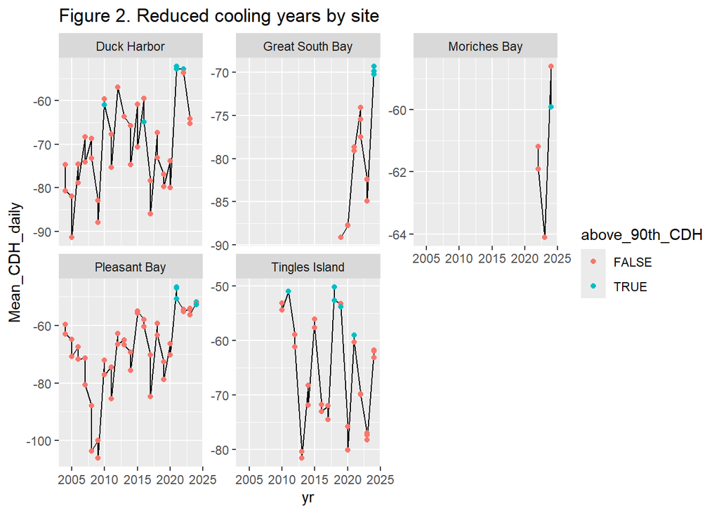

```r
ggplot(site_summary_annual, aes(x = yr, y = Mean_CDH_daily)) +
  geom_line() +
  geom_point(aes(color = above_90th_CDH)) +
  facet_wrap(~Name, scales = "free_y") +
  ggtitle("Figure 2. Reduced cooling years by site")
```

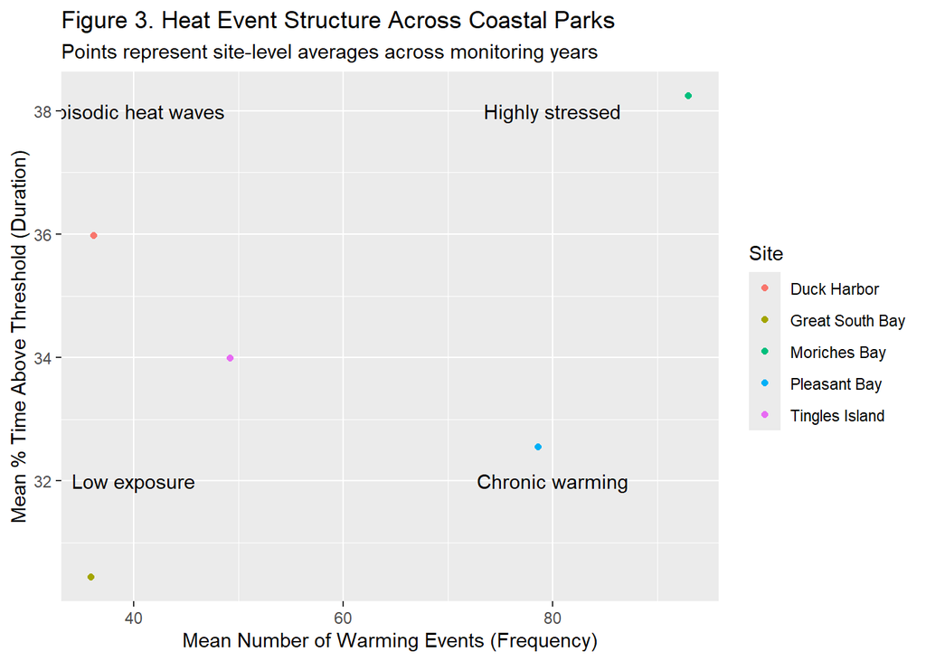

```r
ggplot(site_summary, aes(x = mean_num_warm_events, y = mean_time_above_thres)) +
  geom_point(aes(color = Name)) +
  annotate("text", x = 40, y = 38, label = "Episodic heat waves") +
  annotate("text", x = 40, y = 32, label = "Low exposure") +
  annotate("text", x = 80, y = 38, label = "Highly stressed") +
  annotate("text", x = 80, y = 32, label = "Chronic warming") +
  labs(
      title    = "Figure 3. Heat Event Structure Across Coastal Parks",
      subtitle = "Points represent site-level averages across monitoring years",
      x = "Mean Number of Warming Events (Frequency)",
      y = "Mean % Time Above Threshold (Duration)",
      color = "Site"
    )
```

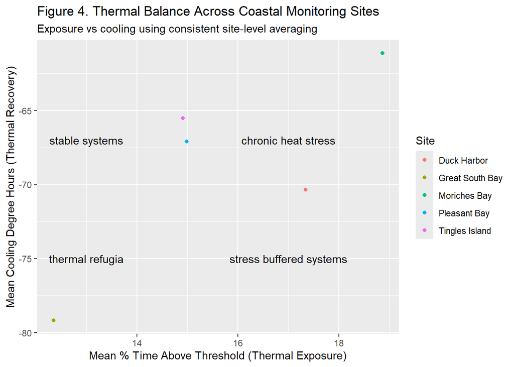

```r
ggplot(site_summary, aes(x = mean_Mean_HDH_daily, y = mean_Mean_CDH_daily)) +
  geom_point(aes(color = Name)) +
  annotate("text", x = 13, y = -67, label = "stable systems") +
  annotate("text", x = 13, y = -75, label = "thermal refugia") +
  annotate("text", x = 17, y = -67, label = "chronic heat stress") +
  annotate("text", x = 17, y = -75, label = "stress buffered systems") +
  labs(
      title    = "Figure 4. Thermal Balance Across Coastal Monitoring Sites",
      subtitle = "Exposure vs cooling using consistent site-level averaging",
      x = "Mean % Time Above Threshold (Thermal Exposure)",
      y = "Mean Cooling Degree Hours (Thermal Recovery)",
      color = "Site"
    )
```

The last two plots really show that these threshold values don’t make sense based on what we know about eelgrass conditions at these sites. First, fig 3 suggests that GSB has low exposure to heat stress and fig 4 suggests that GSB is a thermal refuge but we know this is not the case because eelgrass at GSB has been declining over the years and there is almost nothing left. Second, fig 4 shows Moriches as having chronic heat stress but we know that it is better categorized as a stress buffered system because it also gets lots of cooling from seawater flushing through the inlet. Similarly, fig 3 shows Duck Harbor as having episodic heat waves and fig 4 shows it as having chronic heat stress but we know that Duck has few heating events and also that it gets lots of cooling.